# EDA- CoGo Bike Share Data

Team - 03

2022-10-26

# Data loading and structure

### How the data look like (Summary of the dataset)

```r
colnames(bike)
```

```
##  [1] "ride_id"            "rideable_type"      "started_at"
##  [4] "ended_at"           "start_station_name" "start_station_id"
##  [7] "end_station_name"   "end_station_id"     "start_lat"
## [10] "start_lng"          "end_lat"            "end_lng"
## [13] "member_casual"
```

Below are the overview structure of the whole data frame.

```r
str(bike)
```

```
## 'data.frame':    7416 obs. of  13 variables:
##  $ ride_id           : chr  "726C3A99FFCAE10C" "F1AC3AED5E7498FB" "9C93876268A75FD7" "45AFFC2B7A7BD7C9" ...
##  $ rideable_type     : chr  "classic_bike" "classic_bike" "classic_bike" "classic_bike" ...
##  $ started_at        : chr  "2022-08-18 18:08:30" "2022-08-11 18:28:21" "2022-08-28 19:40:43" "2022-08-15 20:21:00" ...
##  $ ended_at          : chr  "2022-08-18 19:00:37" "2022-08-11 18:44:35" "2022-08-28 20:52:50" "2022-08-15 20:44:37" ...
##  $ start_station_name: chr  "Grandview Library at Oakland Ave" "Jaeger St & Whittier St" "High St & Crestview Rd" "High St & Crestview Rd" ...
##  $ start_station_id  : num  79 59 88 88 88 88 55 55 88 54 ...
##  $ end_station_name  : chr  "Grandview Library at Oakland Ave" "Jaeger St & Whittier St" "High St & Crestview Rd" "High St & Crestview Rd" ...
##  $ end_station_id    : num  79 59 88 88 88 88 48 62 110 54 ...
##  $ start_lat         : num  40 39.9 40 40 40 ...
##  $ start_lng         : num  -83 -83 -83 -83 -83 ...
##  $ end_lat           : num  40 39.9 40 40 40 ...
##  $ end_lng           : num  -83 -83 -83 -83 -83 ...
##  $ member_casual     : chr  "member" "member" "member" "casual" ...
```

```r
xkabledplyhead(bike)
```

Head

| ride_id | rideable_type | started_at | ended_at | start_station_name | start_station_id | end_station_name | end_station_id | start_lat | start_lng | end_lat | end_lng | member_casual |
| --- | --- | --- | --- | --- | --- | --- | --- | --- | --- | --- | --- | --- |
| 726C3A99FFCAE10C | classic_bike | 2022-08-18 18:08:30 | 2022-08-18 19:00:37 | Grandview Library at Oakland Ave | 79 | Grandview Library at Oakland Ave | 79 | 39.9819 | -83.0490 | 39.9819 | -83.0490 | member |
| F1AC3AED5E7498FB | classic_bike | 2022-08-11 18:28:21 | 2022-08-11 18:44:35 | Jaeger St & Whittier St | 59 | Jaeger St & Whittier St | 59 | 39.9446 | -82.9895 | 39.9446 | -82.9895 | member |
| 9C93876268A75FD7 | classic_bike | 2022-08-28 19:40:43 | 2022-08-28 20:52:50 | High St & Crestview Rd | 88 | High St & Crestview Rd | 88 | 40.0225 | -83.0136 | 40.0225 | -83.0136 | member |
| 45AFFC2B7A7BD7C9 | classic_bike | 2022-08-15 20:21:00 | 2022-08-15 20:44:37 | High St & Crestview Rd | 88 | High St & Crestview Rd | 88 | 40.0225 | -83.0136 | 40.0225 | -83.0136 | casual |
| 7F53F5CE67AE059D | electric_bike | 2022-08-18 16:34:55 | 2022-08-18 17:15:32 | High St & Crestview Rd | 88 | High St & Crestview Rd | 88 | 40.0225 | -83.0136 | 40.0225 | -83.0136 | casual |

# Data preparing

### Dealing with NA values for the whole dataframe

```r
print(paste(sum(is.na(bike)), "Number of NA in the data"))
```

```
## [1] "2131 Number of NA in the data"
```

```r
sapply(bike, function(y) sum(length(which(is.na(y)))))
```

```
##            ride_id      rideable_type         started_at           ended_at
##                  0                  0                  0                  0
## start_station_name   start_station_id   end_station_name     end_station_id
##                  0                870                  0               1231
##          start_lat          start_lng            end_lat            end_lng
##                  0                  0                 15                 15
##      member_casual
##                  0
```

Most of NA are contained in the columns `start_station_id and` and `end_station_id`. However, since the name of the station is present we don’t think we should delete the whole row! and for further investigation we subset the NA values to track any pattern.

```r
bike_1 <- subset(bike, !is.na(start_station_id))
bike_final <- subset(bike_1, !is.na(end_station_id))
```

Then, we checked if the data still have NA-Values in the data frame.

```r
print(paste(sum(is.na(bike_final)), "Number of NA in the data"))
```

```
## [1] "0 Number of NA in the data"
```

```r
sapply(bike_final, function(y) sum(length(which(is.na(y)))))
```

```
##            ride_id      rideable_type         started_at           ended_at
##                  0                  0                  0                  0
## start_station_name   start_station_id   end_station_name     end_station_id
##                  0                  0                  0                  0
##          start_lat          start_lng            end_lat            end_lng
##                  0                  0                  0                  0
##      member_casual
##                  0
```

### Change columns type

```r
# change rideable_type/ member_casual to factor
#there three numbers under the factor rideable_type needs to look into!
bike$rideable_type <- factor(bike$rideable_type)
bike$member_casual <- factor(bike$member_casual)

# split started_at/ ended_at to date column and time column
# change start_date/end_date to date type
bike$start_time <- format(as.POSIXct(bike$started_at), format = "%H:%M")
bike$end_time <- format(as.POSIXct(bike$ended_at), format = "%H:%M")
bike$start_date <- as.Date(bike$started_at)
bike$end_date <- as.Date(bike$ended_at)

# Check the structure again

str(bike)
```

```
## 'data.frame':    7416 obs. of  17 variables:
##  $ ride_id           : chr  "726C3A99FFCAE10C" "F1AC3AED5E7498FB" "9C93876268A75FD7" "45AFFC2B7A7BD7C9" ...
##  $ rideable_type     : Factor w/ 3 levels "classic_bike",..: 1 1 1 1 3 3 1 1 1 1 ...
##  $ started_at        : chr  "2022-08-18 18:08:30" "2022-08-11 18:28:21" "2022-08-28 19:40:43" "2022-08-15 20:21:00" ...
##  $ ended_at          : chr  "2022-08-18 19:00:37" "2022-08-11 18:44:35" "2022-08-28 20:52:50" "2022-08-15 20:44:37" ...
##  $ start_station_name: chr  "Grandview Library at Oakland Ave" "Jaeger St & Whittier St" "High St & Crestview Rd" "High St & Crestview Rd" ...
##  $ start_station_id  : num  79 59 88 88 88 88 55 55 88 54 ...
##  $ end_station_name  : chr  "Grandview Library at Oakland Ave" "Jaeger St & Whittier St" "High St & Crestview Rd" "High St & Crestview Rd" ...
##  $ end_station_id    : num  79 59 88 88 88 88 48 62 110 54 ...
##  $ start_lat         : num  40 39.9 40 40 40 ...
##  $ start_lng         : num  -83 -83 -83 -83 -83 ...
##  $ end_lat           : num  40 39.9 40 40 40 ...
##  $ end_lng           : num  -83 -83 -83 -83 -83 ...
##  $ member_casual     : Factor w/ 2 levels "casual","member": 2 2 2 1 1 1 1 2 2 1 ...
##  $ start_time        : chr  "18:08" "18:28" "19:40" "20:21" ...
##  $ end_time          : chr  "19:00" "18:44" "20:52" "20:44" ...
##  $ start_date        : Date, format: "2022-08-18" "2022-08-11" ...
##  $ end_date          : Date, format: "2022-08-18" "2022-08-11" ...
```

# Data analysis & visualazation

### How many users of each membership type we have?

```r
bike %>% count(member_casual)
```

```
##   member_casual    n
## 1        casual 4069
## 2        member 3347
```

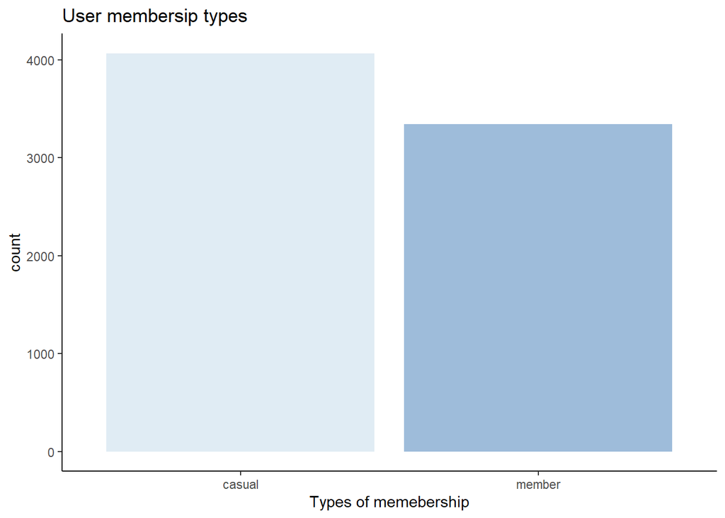

```r
ggplot(bike, aes(member_casual, fill = member_casual))+
  geom_bar()+
  scale_fill_brewer(palette = "BuPu")+
  guides(fill="none")+
  labs(title = "User membersip types", x= "Types of memebership")+
  theme_classic()
```

There are more `causal` users than `annual membership` users, which is 4069 - 3347 = **722** user difference on August 2022. The `causal` users **Single** trip cost 2.25$ per 30min `annual` membership on the other hand cost 85$ a year.

### What is the most frequent bike type used?

```r
bike %>% count(rideable_type)
```

```
##   rideable_type    n
## 1  classic_bike 3401
## 2   docked_bike    3
## 3 electric_bike 4012
```

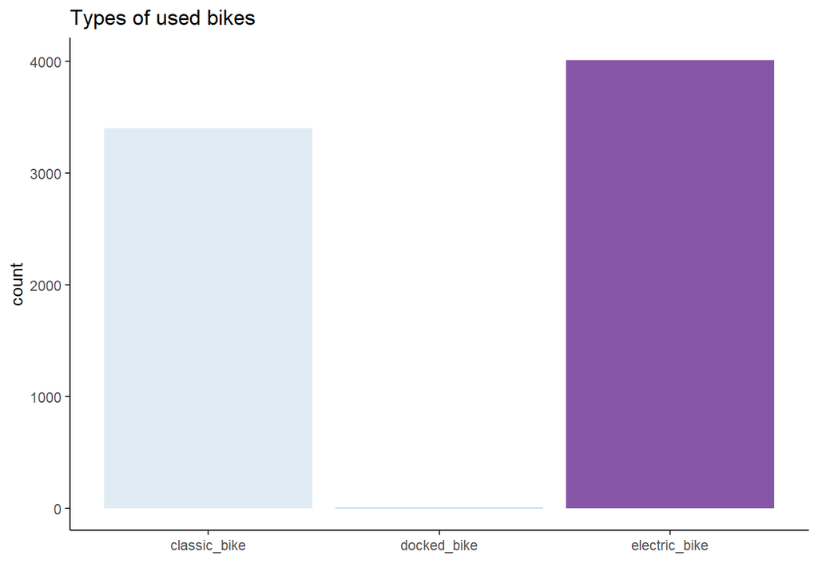

```r
ggplot(bike, aes(rideable_type, fill = rideable_type))+
  geom_bar()+
  scale_fill_brewer(palette = "BuPu")+
  guides(fill="none")+
  labs(title = "Types of used bikes", x = "")+
  theme_classic()
```

There are few users of docked bike type comparing to the others. Docked bike is a bicycles that can be borrowed or rented from an automated station or “docking stations”. It is interesting why would people prefer other types above this type!

### casual vs Annual memeber bike preference

```r
# grouping types of users and counting their used bike type without counting docked_bike because it is only 3 users
members_preferance <- bike %>% group_by(member_casual, rideable_type)%>%
  filter(rideable_type != "docked_bike")%>%
  summarise(used = n())
print(members_preferance)
```

```
## # A tibble: 4 × 3
## # Groups:   member_casual [2]
##   member_casual rideable_type  used
##   <fct>         <fct>         <int>
## 1 casual        classic_bike   1689
## 2 casual        electric_bike  2377
## 3 member        classic_bike   1712
## 4 member        electric_bike  1635
```

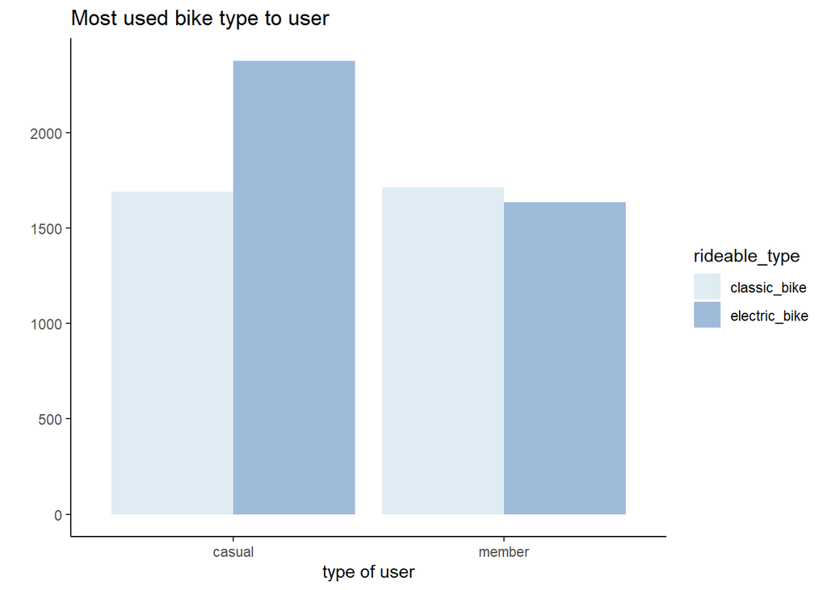

```r
ggplot(members_preferance, aes(x= member_casual,y = used , fill = rideable_type))+
  geom_bar(position='dodge', stat='identity')+
  scale_fill_brewer(palette = "BuPu")+
  labs(title = "Most used bike type to user", x= "type of user", y="")+
  theme_classic()
```

While there is no huge difference between annual members in choosing classic or electric bikes, Casual members choose to use electric bikes over the classic by around 680 user.

### Comparison of users by week.

```r
#extrat only the day and convert it to day of the week
bike$days <- format(bike$start_date, format = "%a")
#convert it to a factor and organize the days order
bike$days <- factor(bike$days, levels = c("Sat", "Sun", "Mon", "Tue", "Wed", "Thu", "Fri" ))

week_count <- bike %>% group_by(days)%>%
  summarise(used = n())
print(week_count)
```

```
## # A tibble: 7 × 2
##   days   used
##   <fct> <int>
## 1 Sat    1204
## 2 Sun     871
## 3 Mon     978
## 4 Tue    1149
## 5 Wed    1205
## 6 Thu     899
## 7 Fri    1110
```

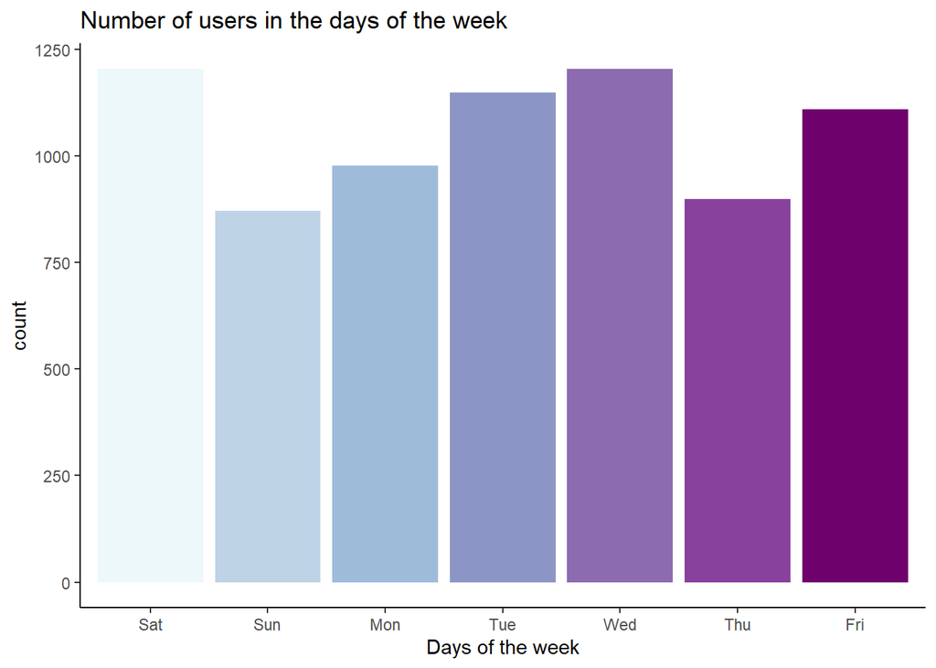

```r
ggplot(bike, aes(days, fill = days))+
  geom_bar()+
  scale_fill_brewer(palette = "BuPu")+
  guides(fill="none")+
  labs(title = "Number of users in the days of the week", x="Days of the week")+
  theme_classic()
```

Saturdays and Wednesdays have the most number of users and Sunday has least.

### When is the highest-lowest time of use of the day?

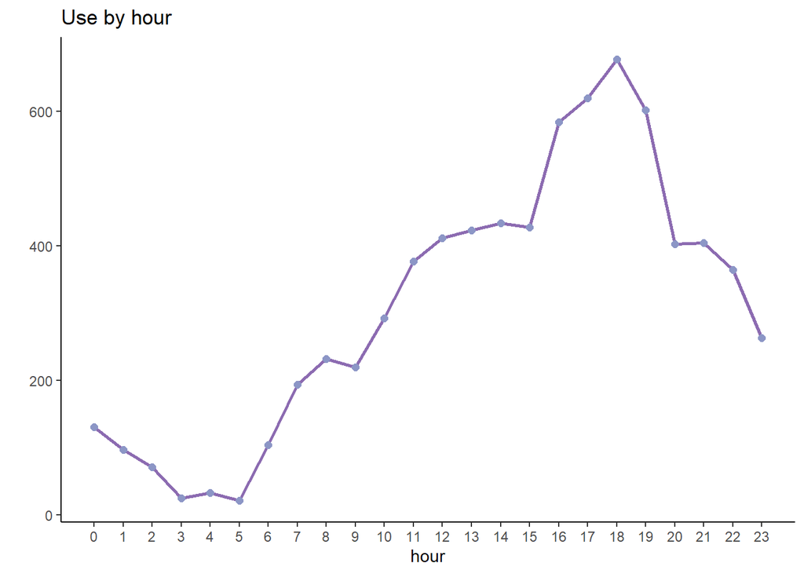

```r
#get only the hour from the time
bike$hour <- NA
bike$hour <- hour(bike$started_at)
sum_hour <- bike %>%
            group_by(hour) %>%
            summarise(sum_hour = length(hour))

ggplot(sum_hour, aes(hour, sum_hour ))+
  geom_line(color = "#8C6BB1", size = 1) +
  geom_point(color = "#8C96C6", size = 2) +
  scale_x_continuous(breaks=seq(0,23,1))+
  labs(title="Use by hour", y = "")+
  theme_classic()
```

The peak hours of August is between 3:00pm to 7:30pm with above 400 user.

### What is the hourly use of each day?

```r
sum_hour <- bike %>%
            group_by(days, hour)%>% summarise(count = n())
```

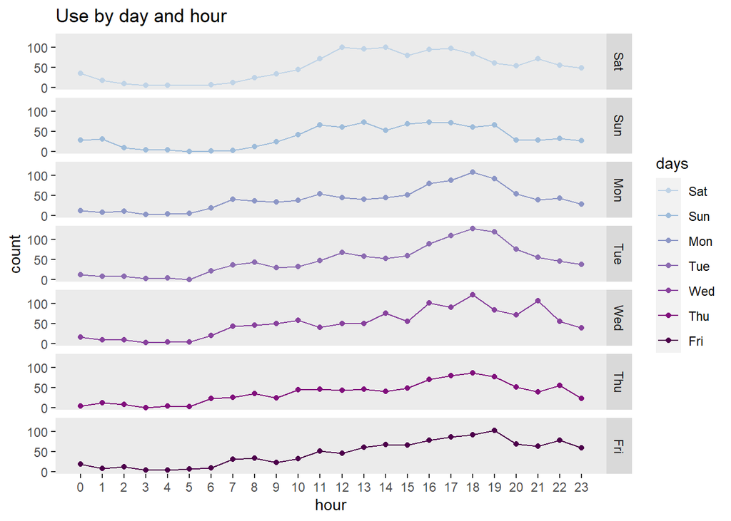

```r
ggplot(data = sum_hour, aes(x = hour, y = count,  color = days))+
  geom_point() + geom_line(aes(group = 1))+
  facet_grid(rows = vars(days))+
  scale_color_manual(values=c("#BFD3E6", "#9EBCDA" ,"#8C96C6" ,"#8C6BB1", "#88419D", "#810F7C", "#4D004B"))+
  labs(title= "Use by day and hour")+
  scale_y_continuous(breaks=seq(0,130,50))+
  scale_x_continuous(breaks=seq(0,23,1))+
    theme(
    plot.background = element_blank(),
    panel.grid.major = element_blank(),
    panel.grid.minor = element_blank(),
    panel.border = element_blank()
  )
```

During the *weekend* hours, the rush hour start at 9:00am while in the *weekdays* it starts earlier at 6:00am. Also, in most of the *weekdays* the line does not drop until 9:00pm but it drop a little earlier during the *weekends* at 8:00pm.

### Where are the most used stations

```r
#subset without the na
end_station <- subset(bike, (!is.na(bike[,11])) & (!is.na(bike[,12])))

library(ggmap)
```

[figure not shown]

```r
register_google(key = "AIzaSyA0ztoTDco-EGhyGNmKM1EfUy3pYvlQbQQ")
#end station
bikemap <-ggmap(get_googlemap(center = c(lon = -82.99879, lat=  39.96118),
                    maptype = 'terrain',
                    color = "color",
                    zoom = 11))
bikemap1 <- bikemap + stat_bin2d(data = end_station, aes(x =end_lng, y = end_lat, size = end_station_id, color =end_station_id), alpha = 0.7)+labs(title = "End Stations")+scale_fill_gradient(low = "blue", high = "red", name ="user")


#start stations

bikemap2 <- bikemap + stat_bin2d(data = bike, aes(x =start_lng, y = start_lat, size = start_station_id, color =start_station_id), alpha =0.7)+labs(title = "Start Stations")+scale_fill_gradient(low = "blue", high = "red", name = "user")

print(bikemap1)
```

[figure not shown]

```r
print(bikemap2)
```

```r
bike_1 <- subset(bike, !is.na(start_station_id))
bike_final <- subset(bike_1, !is.na(end_station_id))
group_location1 <- bike_final%>%
                  group_by(start_station_name)%>%
                  summarise(count = n())%>%
                  arrange(desc(count))%>%
                  slice(1:5)
group_location2 <- bike_final%>%
                  group_by(end_station_name)%>%
                  summarise(count = n())%>%
                  arrange(desc(count))%>%
                  slice(1:5)
xkabledply(group_location1 , title = "Top 5 start locations")
```

Top 5 start locations

| start_station_name | count |
| --- | --- |
| Bicentennial Park | 386 |
| North Bank Park | 200 |
| High St & Broad St | 165 |
| Scioto Audubon Center | 164 |
| High St & Warren | 135 |

```r
xkabledply(group_location2 , title = "Top 5 end locations")
```

Top 5 end locations

| end_station_name | count |
| --- | --- |
| Bicentennial Park | 378 |
| North Bank Park | 210 |
| High St & Warren | 167 |
| Scioto Audubon Center | 165 |
| High St & Broad St | 154 |

# Summary of Statistics & Testing：

### Summary Statistics

First of all, let’s look at the summary statistic of these two variables

```r
bike$Startedat = as.POSIXct(bike$started_at, format = "%Y-%m-%d %H:%M:%S")
bike$enddat = as.POSIXct(bike$ended_at, format = "%Y-%m-%d %H:%M:%S")

bike$Total_Time <- round(as.numeric(difftime(bike$enddat, bike$Startedat, units = "mins")),2)
bike_time <- subset(bike, !is.na(Total_Time), select=Total_Time)

summary(bike_time)
```

```
##    Total_Time
##  Min.   :   0.00
##  1st Qu.:   7.37
##  Median :  13.03
##  Mean   :  26.53
##  3rd Qu.:  25.66
##  Max.   :1499.92
```

According to the time statistics we can see that, overall, nearly 25% of customers use less than 7-minutes, nearly 50% of customers use less than 13-minutes, and nearly 75% of all customers use less than 25 minutes;

we don’t know anything about the proportion about the time boundary and we could not figure out how many users are riding the bike for more than 30 mins or 45 mins (as after 30 mins and 45 minutes the price increases), so we further drilled down our analytics.

we know that the price for casual users increase after 30 mins and for annual members it increases after 45 mins so we divided our data into different groups based on members_casual and bike_type to do the analysis in detailed； Moreover, we have an max value 1499, we want to see which group it is located at and see if that’s an occasional case for that group.

### Membership vs Casual Customer:

We subset the time difference variable by member_casual categories.

```r
membership <- subset(bike, !is.na(Total_Time)&member_casual=='member', select=c(member_casual, Total_Time))

casual <- subset(bike, !is.na(Total_Time)&member_casual=='casual', select=c(member_casual, Total_Time))

print('Member_customers structure')
```

```
## [1] "Member_customers structure"
```

```r
str(membership)
```

```
## 'data.frame':    3347 obs. of  2 variables:
##  $ member_casual: Factor w/ 2 levels "casual","member": 2 2 2 2 2 2 2 2 2 2 ...
##  $ Total_Time   : num  52.1 16.2 72.1 6.2 10 ...
```

```r
print('')
```

```
## [1] ""
```

```r
print('')
```

```
## [1] ""
```

```r
print('Casual_customers structure')
```

```
## [1] "Casual_customers structure"
```

```r
str(casual)
```

```
## 'data.frame':    4069 obs. of  2 variables:
##  $ member_casual: Factor w/ 2 levels "casual","member": 1 1 1 1 1 1 1 1 1 1 ...
##  $ Total_Time   : num  23.6 40.6 40.3 8.3 31.6 ...
```

We check the basic summary statistics for these two subsets：

```r
print('Summary Statistic for Members')
```

```
## [1] "Summary Statistic for Members"
```

```r
summary(membership$Total_Time)
```

```
##    Min. 1st Qu.  Median    Mean 3rd Qu.    Max.
##    0.03    5.97    9.67   12.92   15.56  283.40
```

```r
sd(membership$Total_Time)
```

```
## [1] 12.75209
```

```r
print('')
```

```
## [1] ""
```

```r
print('')
```

```
## [1] ""
```

```r
print('Summary Statistic for Casual')
```

```
## [1] "Summary Statistic for Casual"
```

```r
summary(casual$Total_Time)
```

```
##    Min. 1st Qu.  Median    Mean 3rd Qu.    Max.
##    0.00    9.37   18.10   37.72   36.93 1499.92
```

```r
sd(casual$Total_Time)
```

```
## [1] 108.3266
```

Because the time boundary (the time that will charge extra fee) for casual customers is 30 minutes and 45 minutes for member customers, so we want to check what’s the proportion of these two types of customers who are using more time than the time boundary, and then decide if we can do some price adjustment So first, we need to check their data distribution

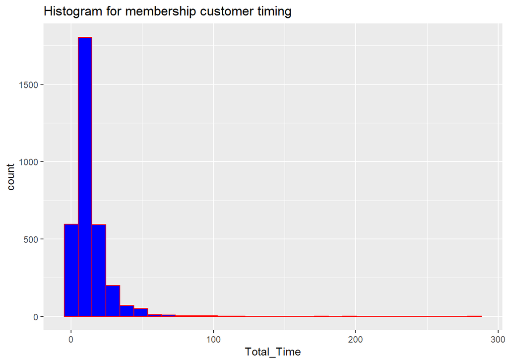

```r
ggplot(data=membership, mapping = aes(Total_Time))+geom_histogram(col='red', fill='blue')+labs(title='Histogram for membership customer timing')
```

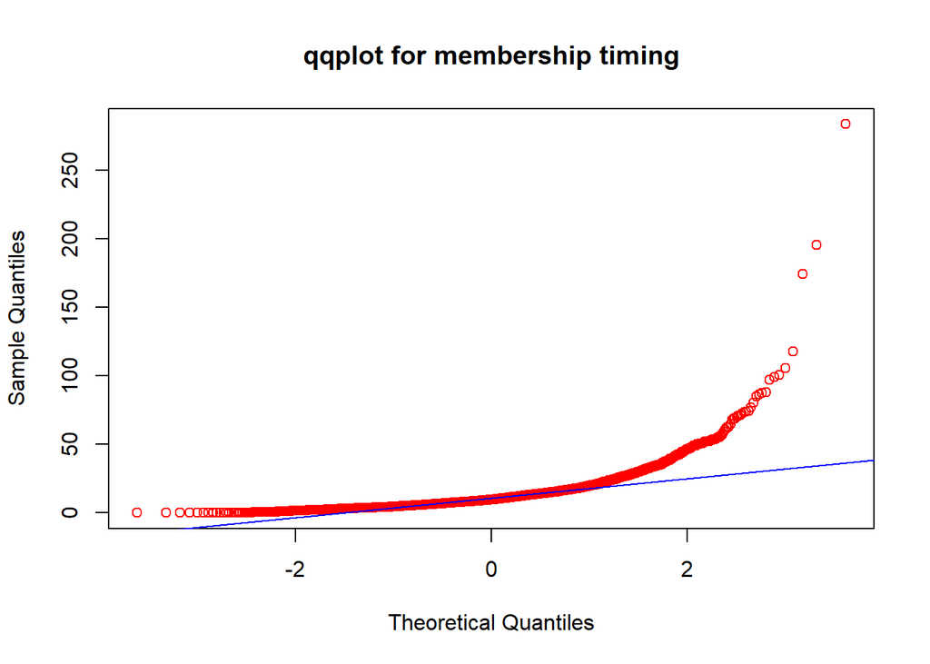

```r
qqnorm(membership$Total_Time, main='qqplot for membership timing', col='red')
qqline(membership$Total_Time, col='blue')
```

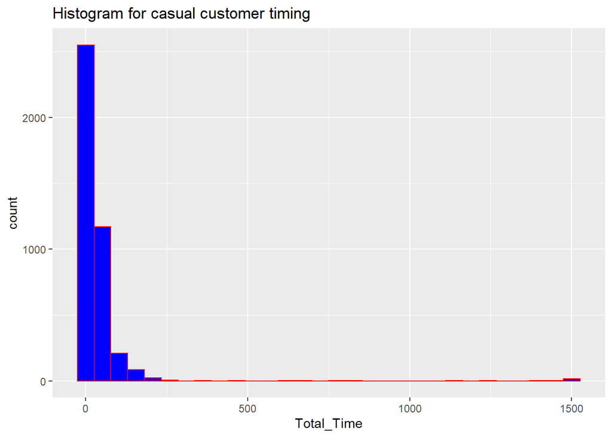

```r
ggplot(data=casual, mapping = aes(Total_Time))+geom_histogram(col='red', fill='blue')+labs(title='Histogram for casual customer timing')
```

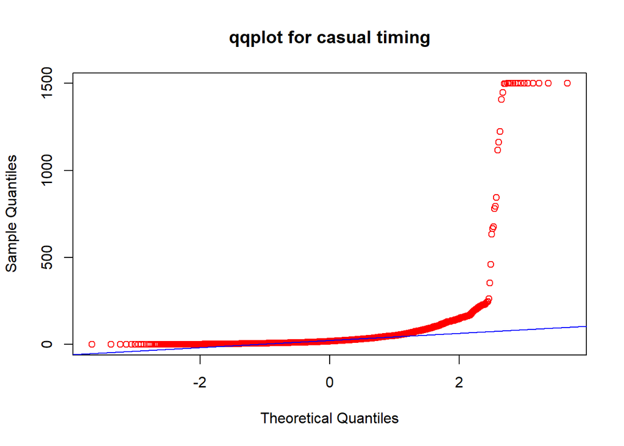

```r
qqnorm(casual$Total_Time, main='qqplot for casual timing', col='red')
qqline(casual$Total_Time, col='blue')
```

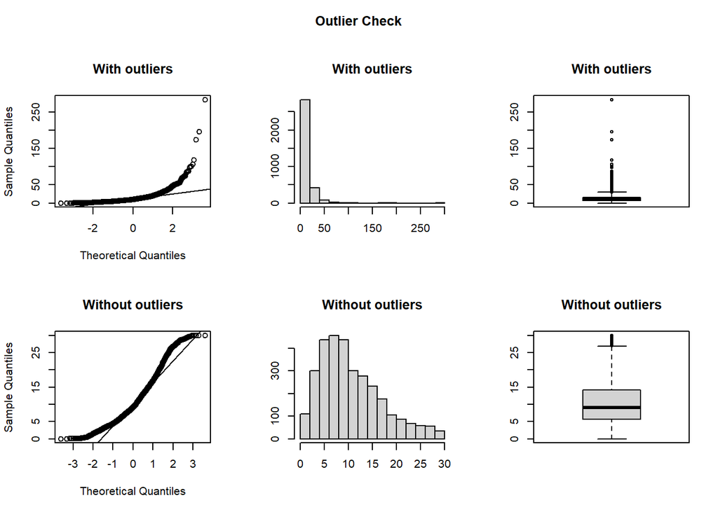

```
## Outliers identified: 221
## Proportion (%) of outliers: 7.1
## Mean of the outliers: 46.73
## Mean without removing outliers: 12.92
## Mean if we remove outliers: 10.53
## Outliers successfully removed
```

```r
membership_clean_1 <- outlierKD2 (membership, Total_Time, rm=T, boxplt = TRUE, qqplt = TRUE)
```

```r
print('Summary Statistic for cleaned membership time')
```

```
## [1] "Summary Statistic for cleaned membership time"
```

```r
summary(membership_clean_1)
```

```
##  member_casual   Total_Time
##  casual:   0   Min.   : 0.030
##  member:3347   1st Qu.: 5.705
##                Median : 9.120
##                Mean   :10.528
##                3rd Qu.:14.178
##                Max.   :29.920
##                NA's   :221
```

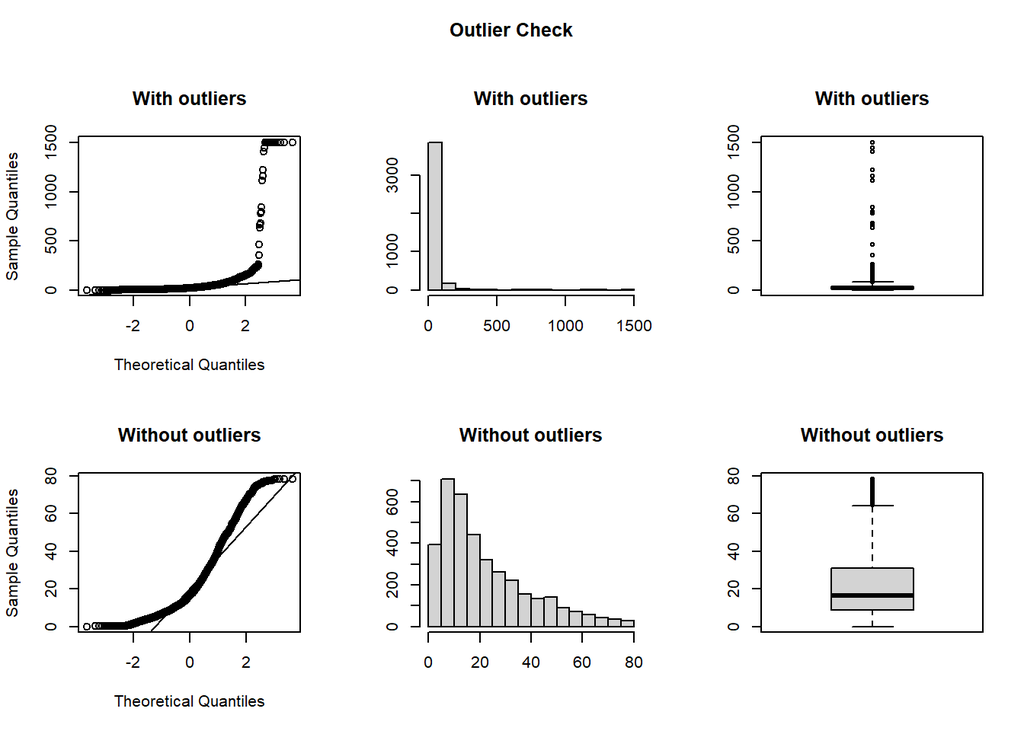

```
## Outliers identified: 343
## Proportion (%) of outliers: 9.2
## Mean of the outliers: 210.94
## Mean without removing outliers: 37.72
## Mean if we remove outliers: 21.77
## Outliers successfully removed
```

```r
casual_clean_1 <- outlierKD2 (casual, Total_Time, rm=T, boxplt=TRUE, qqplt = TRUE)
```

```r
print('Summary Statistic for cleaned casual time')
```

```
## [1] "Summary Statistic for cleaned casual time"
```

```r
summary(casual_clean_1)
```

```
##  member_casual   Total_Time
##  casual:4069   Min.   : 0.000
##  member:   0   1st Qu.: 8.755
##                Median :16.450
##                Mean   :21.773
##                3rd Qu.:30.918
##                Max.   :78.120
##                NA's   :343
```

Above we cleaned the outliers and replaced it with null values; to see the charts more clear, we removed the null values and created histogram and boxplot again for both of these two cetegories.

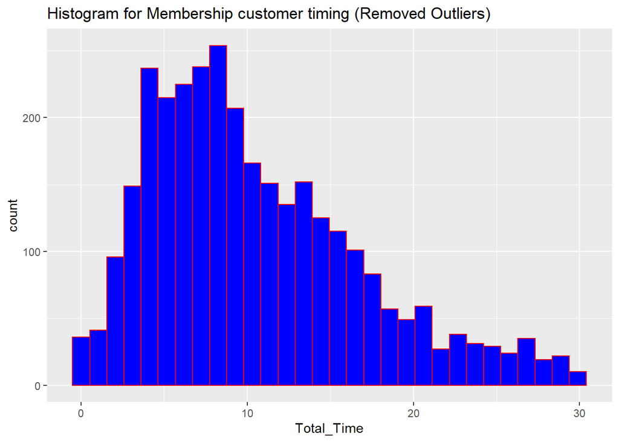

```r
casual_clean <- subset(casual_clean_1, !is.na(Total_Time))
membership_clean <- subset(membership_clean_1, !is.na(Total_Time))


ggplot(data=membership_clean, mapping = aes(Total_Time))+geom_histogram(col='red', fill='blue')+labs(title='Histogram for Membership customer timing (Removed Outliers)')
```

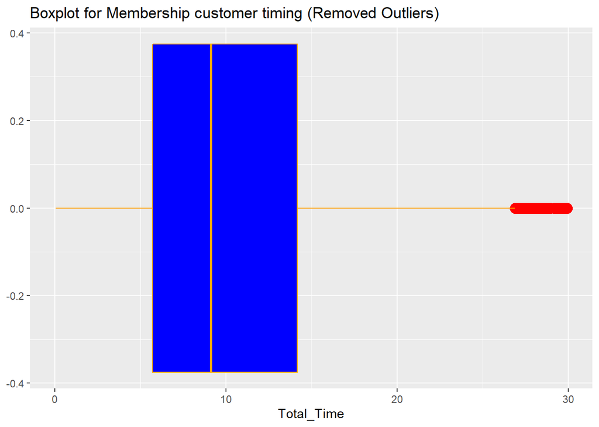

```r
ggplot(data=membership_clean, aes(Total_Time)) + geom_boxplot (colour='orange', fill='blue', outlier.colour='red', outlier.size = 4)+labs(title='Boxplot for Membership customer timing (Removed Outliers)')
```

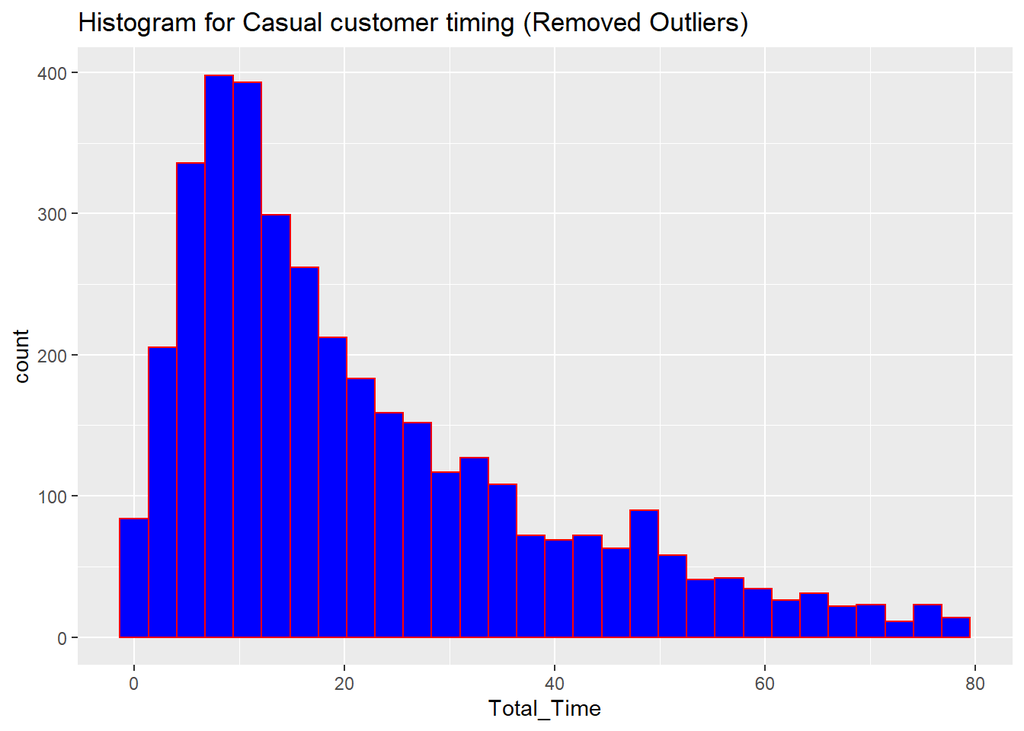

```r
ggplot(data=casual_clean, mapping = aes(Total_Time))+geom_histogram(col='red', fill='blue')+labs(title='Histogram for Casual customer timing (Removed Outliers)')
```

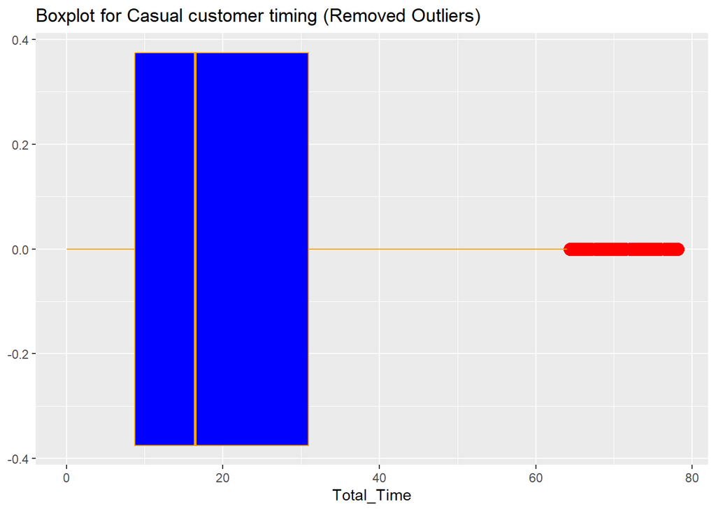

```r
ggplot(data=casual_clean, aes(Total_Time)) + geom_boxplot (colour='orange', fill='blue', outlier.colour='red', outlier.size = 4)+labs(title='Boxplot for Casual customer timing (Removed Outliers)')
```

```r
print('The proportion of casual customers use more than 30mins are about：')
```

```
## [1] "The proportion of casual customers use more than 30mins are about："
```

```r
pnorm(30, mean(casual_clean$Total_Time), sd(casual_clean$Total_Time),lower.tail=FALSE)
```

```
## [1] 0.3163245
```

```r
print('')
```

```
## [1] ""
```

```r
print('')
```

```
## [1] ""
```

```r
print('The proportion of member customers use more than 45mins are about：')
```

```
## [1] "The proportion of member customers use more than 45mins are about："
```

```r
pnorm(45, mean(membership_clean$Total_Time), sd(membership_clean$Total_Time),lower.tail=FALSE)
```

```
## [1] 2.864473e-08
```

According to the probability information, it seems like the casual customers less care about the boundary price and will use much more time in comparison to the membership customers; To further test our assumption that casual customer always use more time than member, we need to test if the average time for using shared bike are the same. Firstly, we can use the averages in August to construct and compare two Confidence Interval, say the default confident level is 95%, then, we’ll make a null hypothesis that is “average time of member is less than average time of casual/difference between member average time and casual average time is less than zero” and test it with T-Test (because we want to test the average with only two categories, which are ‘member’ and ‘casual’) if our assumption is more reliable (or even true), we may suggest the company can increase their profit margin by slightly increasing the boundary price for casual customers because casual customers may be more acceptable for the price increment. (Because for now the August data is our sample so we need to use the T-Test to construct CI)

```r
print('CI for Casual')
```

```
## [1] "CI for Casual"
```

```r
ttest2 <- t.test(casual_clean$Total_Time)
ttest2$conf.int
```

```
## [1] 21.21988 22.32555
## attr(,"conf.level")
## [1] 0.95
```

```r
print('')
```

```
## [1] ""
```

```r
print('CI for Membership')
```

```
## [1] "CI for Membership"
```

```r
ttest1 <- t.test(membership_clean$Total_Time)
ttest1$conf.int
```

```
## [1] 10.30522 10.75073
## attr(,"conf.level")
## [1] 0.95
```

According to the CI Information above, se can see there’s no overlap between these two CIs, and the interval for average time of casual customers are much larger than the interval for average time of member customers. Secondly, we can do a hypothesis testing between these 2 averages. We set our null hypothesis H0: Two averages of total time are same, and just in case, we set our significance level as 5%. (for a wider range, let’s say august data is just a sample, but the data for the whole year is the population)

```r
ttest2sample_total_time <- t.test(casual_clean$Total_Time, membership_clean$Total_Time, mu=0, alternative = 'greater')
# Have to prove casual_clean at first argument because our alternative hypothesis is 'avg(casual)-avg(membership)>0' instead of 'avg(membership)-avg(casual)>0；if we put membership_clean at the first argument, then the result will have a extremely large p-value
ttest2sample_total_time
```

```
##
##  Welch Two Sample t-test
##
## data:  casual_clean$Total_Time and membership_clean$Total_Time
## t = 36.99, df = 4879.3, p-value < 2.2e-16
## alternative hypothesis: true difference in means is greater than 0
## 95 percent confidence interval:
##  10.74461      Inf
## sample estimates:
## mean of x mean of y
##  21.77271  10.52797
```

According to the p-value for differences in total time between two types of customers is 2.2e-16, because our p-value is extremely small, so the data presented is enough evidence to reject null hypothesis H0, and we can’t say the average riding time of membership is less than or the same as average riding time of casual customers.

### Classic Bike vs Electric Bike:

Except subseting the time based on membership type, we can also subset the time based on bike types

```r
classic_bike <- subset(bike, !is.na(Total_Time)&rideable_type=='classic_bike', select=c(rideable_type, Total_Time))

electric_bike <- subset(bike, !is.na(Total_Time)&rideable_type=='electric_bike', select=c(rideable_type, Total_Time))

print('classic_bike structure：')
```

```
## [1] "classic_bike structure："
```

```r
str(classic_bike)
```

```
## 'data.frame':    3401 obs. of  2 variables:
##  $ rideable_type: Factor w/ 3 levels "classic_bike",..: 1 1 1 1 1 1 1 1 1 1 ...
##  $ Total_Time   : num  52.1 16.2 72.1 23.6 8.3 ...
```

```r
print('')
```

```
## [1] ""
```

```r
print('')
```

```
## [1] ""
```

```r
print('electric_bike structure：')
```

```
## [1] "electric_bike structure："
```

```r
str(electric_bike)
```

```
## 'data.frame':    4012 obs. of  2 variables:
##  $ rideable_type: Factor w/ 3 levels "classic_bike",..: 3 3 3 3 3 3 3 3 3 3 ...
##  $ Total_Time   : num  40.6 40.3 18.5 19.1 20.1 ...
```

Then, we’ll check their summary statistics for both of the subsets

```r
print('Summary Statistic for classic bike')
```

```
## [1] "Summary Statistic for classic bike"
```

```r
summary(classic_bike$Total_Time)
```

```
##    Min. 1st Qu.  Median    Mean 3rd Qu.    Max.
##    0.03    8.50   15.05   33.43   28.57 1499.92
```

```r
sd(classic_bike$Total_Time)
```

```
## [1] 116.5106
```

```r
print('')
```

```
## [1] ""
```

```r
print('')
```

```
## [1] ""
```

```r
print('Summary Statistic for electric bike')
```

```
## [1] "Summary Statistic for electric bike"
```

```r
summary(electric_bike$Total_Time)
```

```
##    Min. 1st Qu.  Median    Mean 3rd Qu.    Max.
##    0.00    6.52   11.32   20.64   22.49  230.53
```

```r
sd(electric_bike$Total_Time)
```

```
## [1] 27.08984
```

Recall the time boundary is 30-mins (for casual customers) and 45-mins (for member customers) for extra price, then, same logic： We can see that there’s about less than 25% of people using more than 28mins for classic bike and more than 22 mins for electric bike, but these information was not enough, we want to know the information about proportion related with the time boundaries, so that we can which type of bike is more in favor and make some recommendations about the bike storage plan for the company, so then we need to check the distribution of these two data for more detailed information.

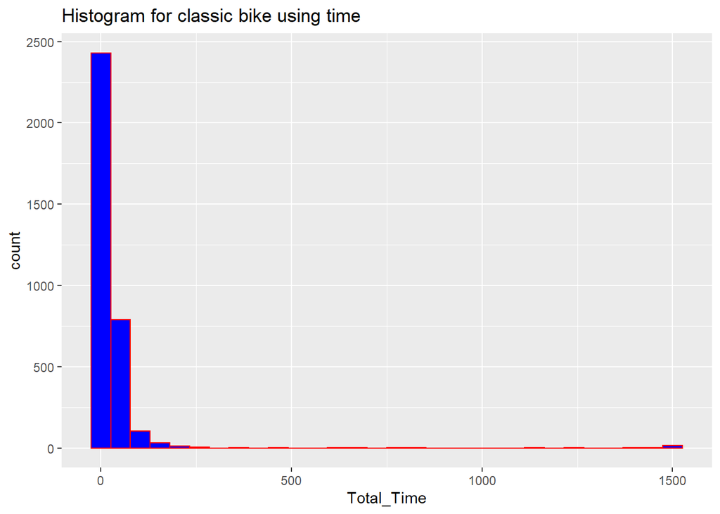

```r
ggplot(data=classic_bike, mapping = aes(Total_Time))+geom_histogram(col='red', fill='blue')+labs(title='Histogram for classic bike using time')
```

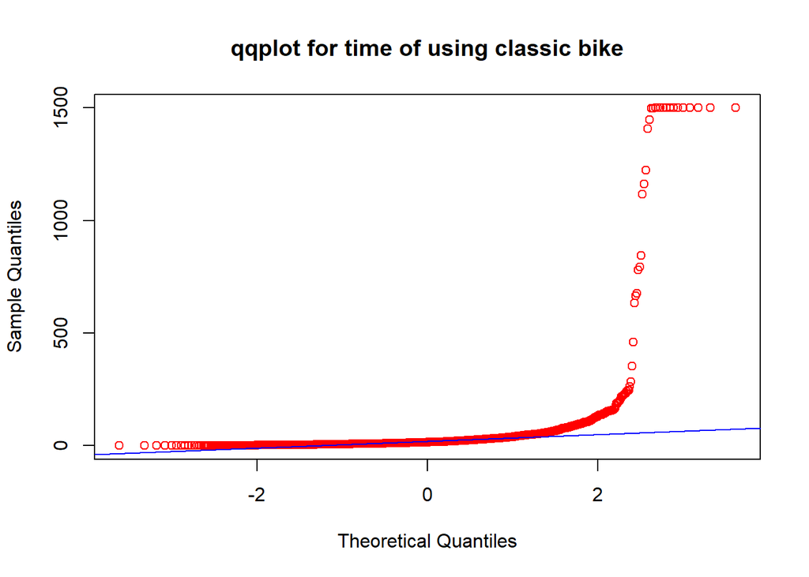

```r
qqnorm(classic_bike$Total_Time, main='qqplot for time of using classic bike', col='red')
qqline(classic_bike$Total_Time, col='blue')
```

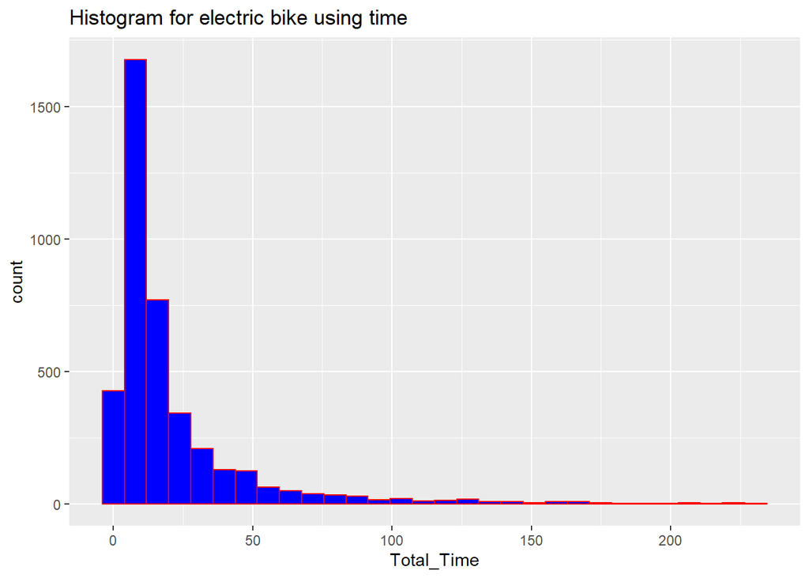

```r
ggplot(data=electric_bike, mapping = aes(Total_Time))+geom_histogram(col='red', fill='blue')+labs(title='Histogram for electric bike using time')
```

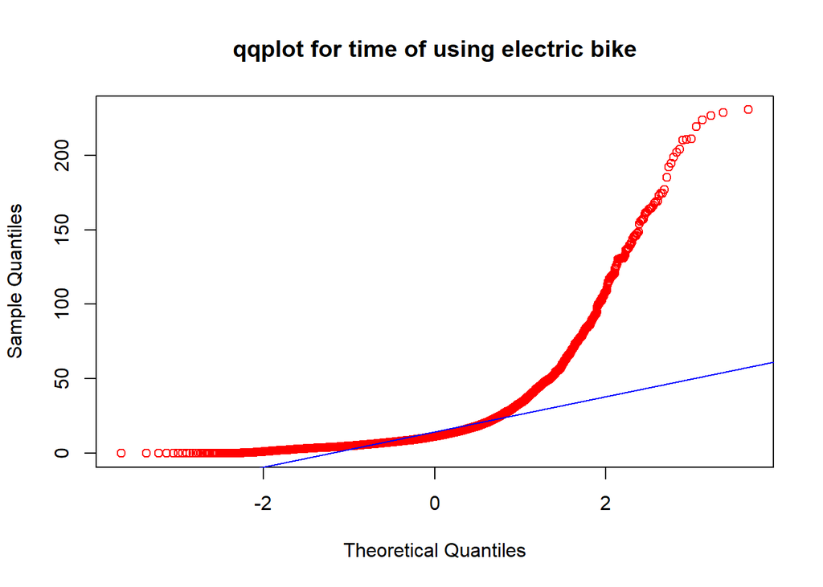

```r
qqnorm(electric_bike$Total_Time, main='qqplot for time of using electric bike', col='red')
qqline(electric_bike$Total_Time, col='blue')
```

We can see that both the data are highly right-skewed, which means there are some few extremely large outliers in the data, so we’ll exclude those outliers first

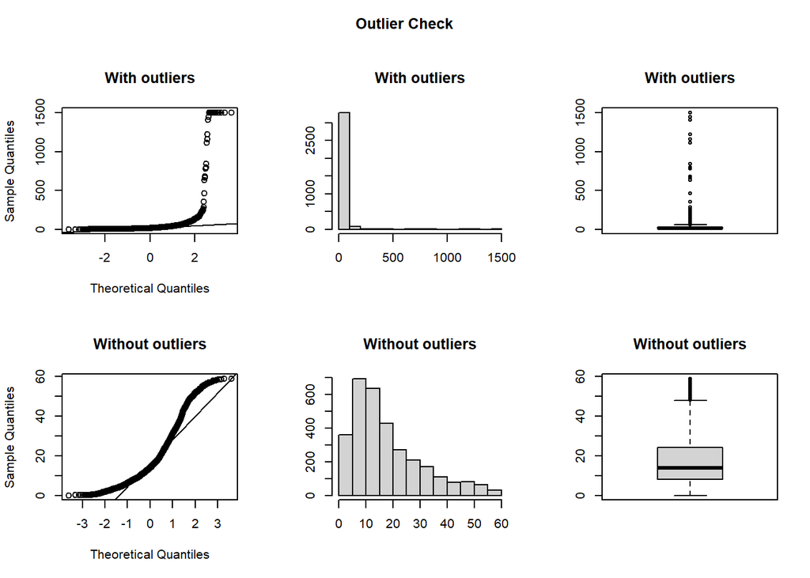

```
## Outliers identified: 270
## Proportion (%) of outliers: 8.6
## Mean of the outliers: 217.15
## Mean without removing outliers: 33.43
## Mean if we remove outliers: 17.58
## Outliers successfully removed
```

```r
classic_clean_1 <- ezids::outlierKD2 (classic_bike, Total_Time, rm=T, boxplt = TRUE, qqplt = TRUE)
```

```r
summary(classic_clean_1$Total_Time)
```

```
##    Min. 1st Qu.  Median    Mean 3rd Qu.    Max.    NA's
##    0.03    8.08   13.78   17.58   24.02   58.65     270
```

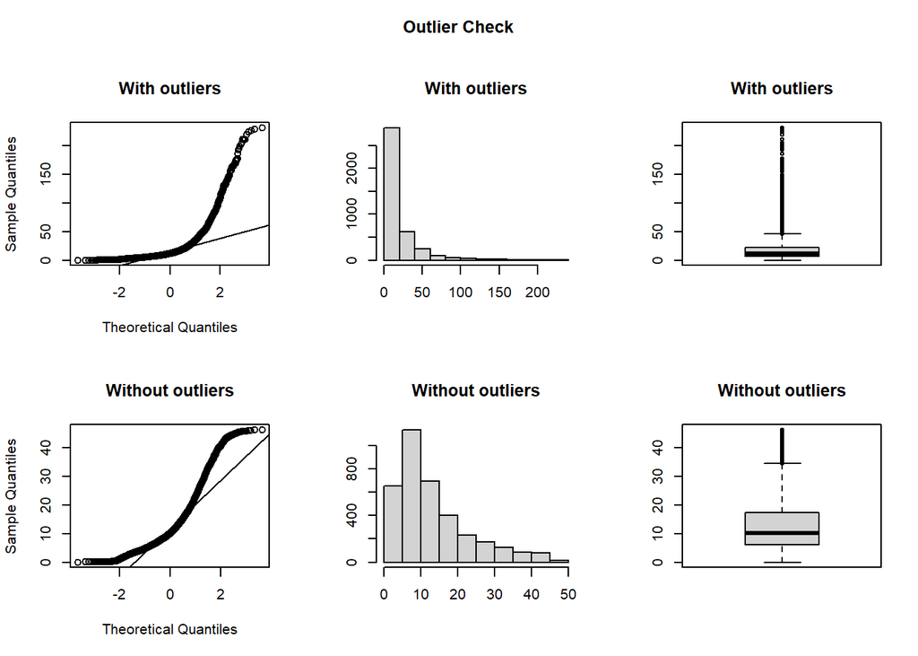

```
## Outliers identified: 422
## Proportion (%) of outliers: 11.8
## Mean of the outliers: 84.42
## Mean without removing outliers: 20.64
## Mean if we remove outliers: 13.14
## Outliers successfully removed
```

```r
electric_clean_1 <- ezids::outlierKD2 (electric_bike, Total_Time, rm=T, boxplt = TRUE, qqplt = TRUE)
```

```r
summary(electric_clean_1$Total_Time)
```

```
##    Min. 1st Qu.  Median    Mean 3rd Qu.    Max.    NA's
##    0.00    6.05   10.06   13.14   17.41   46.20     422
```

After the outliers was removed, we clear the null values again

```r
library(ggplot2)

classic_clean <- subset(classic_clean_1, !is.na(Total_Time))
electric_clean <- subset(electric_clean_1, !is.na(Total_Time))
```

For clear visual, we create the charts for both categories again.

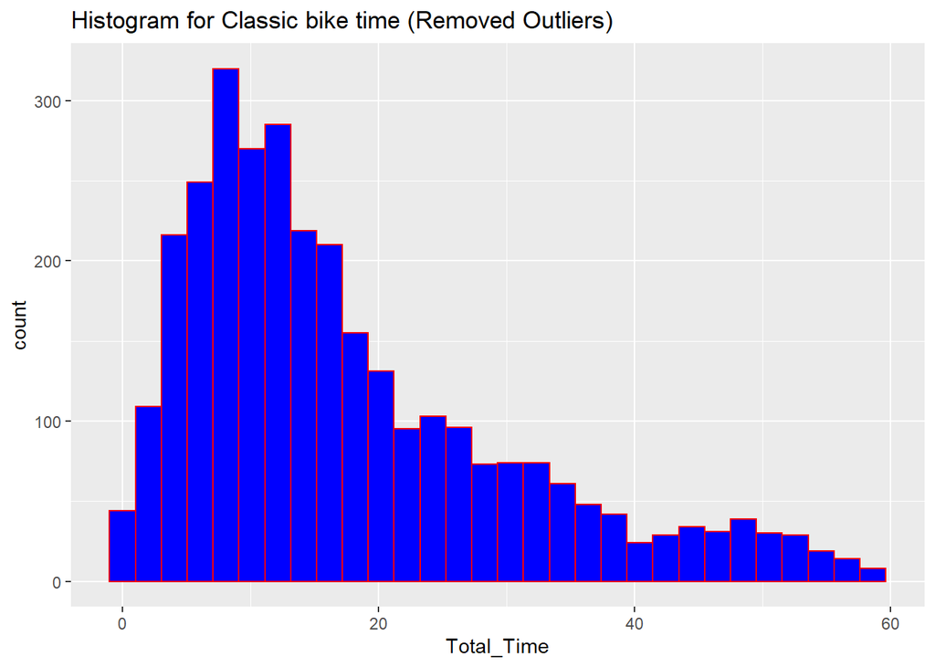

```r
ggplot(data=classic_clean, mapping = aes(Total_Time))+geom_histogram(col='red', fill='blue')+labs(title='Histogram for Classic bike time (Removed Outliers)')
```

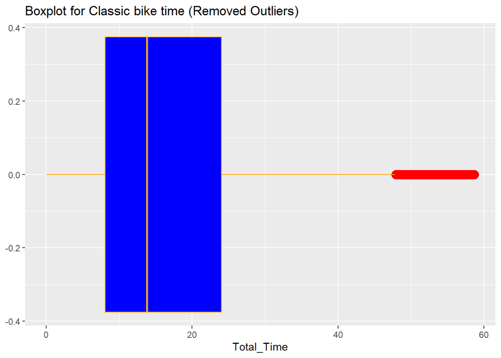

```r
ggplot(data=classic_clean, aes(Total_Time)) + geom_boxplot (colour='orange', fill='blue', outlier.colour='red', outlier.size = 4)+labs(title='Boxplot for Classic bike time (Removed Outliers)')
```

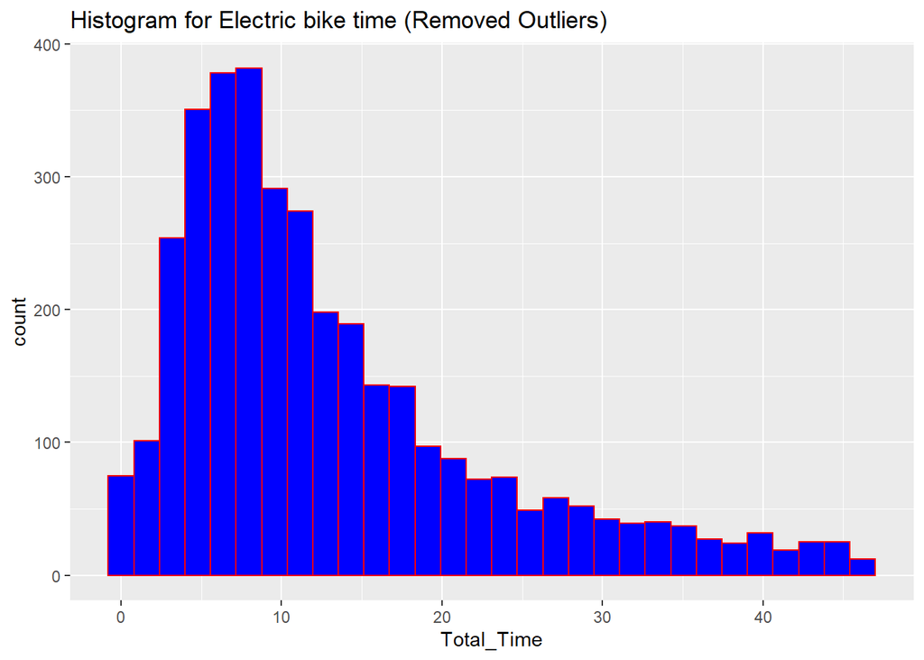

```r
ggplot(data=electric_clean, mapping = aes(Total_Time))+geom_histogram(col='red', fill='blue')+labs(title='Histogram for Electric bike time (Removed Outliers)')
```

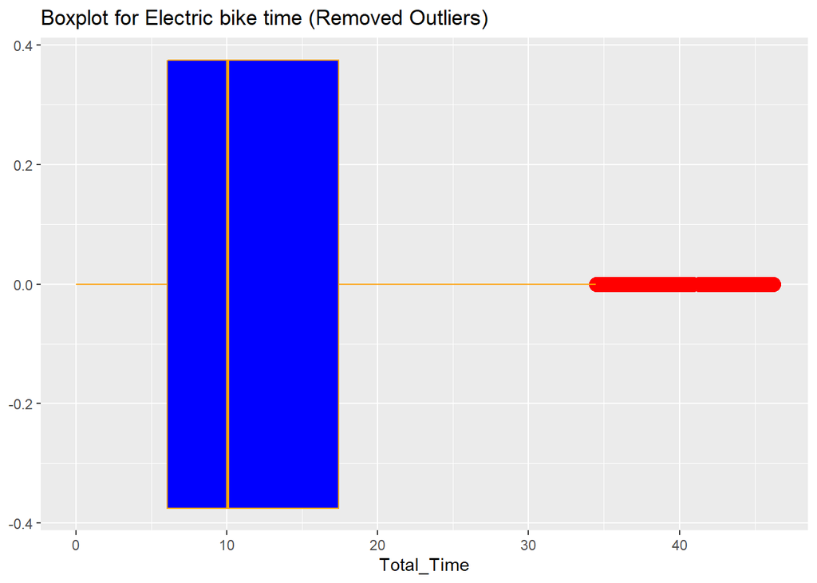

```r
ggplot(data=electric_clean, aes(Total_Time)) + geom_boxplot (colour='orange', fill='blue', outlier.colour='red', outlier.size = 4)+labs(title='Boxplot for Electric bike time (Removed Outliers)')
```

```r
print('The proportion of using classic bike more than 30mins is about：')
```

```
## [1] "The proportion of using classic bike more than 30mins is about："
```

```r
pnorm(30, mean(classic_clean$Total_Time), sd(classic_clean$Total_Time),lower.tail=FALSE)
```

```
## [1] 0.1671469
```

```r
print('')
```

```
## [1] ""
```

```r
print('')
```

```
## [1] ""
```

```r
print('The proportion of using electric bike more than 30mins is about：')
```

```
## [1] "The proportion of using electric bike more than 30mins is about："
```

```r
pnorm(30, mean(electric_clean$Total_Time), sd(electric_clean$Total_Time),lower.tail=FALSE)
```

```
## [1] 0.04485024
```

2). 45 mins (Time boundary for members)：

```r
print('The proportion of using classic bike more than 45mins is about：')
```

```
## [1] "The proportion of using classic bike more than 45mins is about："
```

```r
pnorm(45, mean(classic_clean$Total_Time), sd(classic_clean$Total_Time),lower.tail=FALSE)
```

```
## [1] 0.01650851
```

```r
print('')
```

```
## [1] ""
```

```r
print('')
```

```
## [1] ""
```

```r
print('The proportion of using electric bike more than 45mins is about：')
```

```
## [1] "The proportion of using electric bike more than 45mins is about："
```

```r
pnorm(45, mean(electric_clean$Total_Time), sd(electric_clean$Total_Time),lower.tail=FALSE)
```

```
## [1] 0.0006705068
```

According to the probability for both boundaries, we can see that no matter what time boundary is, more than 30 or 45 minutes, the proportion of using classic bike is always more than the proportion of using electric bike. However, we need to test its reliability so that we can have more confidence to recommend the company to adjust their bike storing plan next year (so now suppose August data is just one sample, and the true population is the data from every year). We will construct the Confidence Interval and do the T-Test for comparing these two averages

```r
print('CI for Classic bike time')
```

```
## [1] "CI for Classic bike time"
```

```r
ttest3 <- t.test(classic_clean$Total_Time)
ttest3$conf.int
```

```
## [1] 17.13267 18.03395
## attr(,"conf.level")
## [1] 0.95
```

```r
print('')
```

```
## [1] ""
```

```r
print('CI for Electric bike time')
```

```
## [1] "CI for Electric bike time"
```

```r
ttest4 <- t.test(electric_clean$Total_Time)
ttest4$conf.int
```

```
## [1] 12.81838 13.46847
## attr(,"conf.level")
## [1] 0.95
```

According to the results above, we can see that there’s no overlap between classic-bike’s CI and electric-bike’s CI.

```r
ttest2sample_total_time_2 <- t.test(classic_clean$Total_Time, electric_clean$Total_Time, mu=0, alternative = 'greater' )
ttest2sample_total_time_2
```

```
##
##  Welch Two Sample t-test
##
## data:  classic_clean$Total_Time and electric_clean$Total_Time
## t = 15.667, df = 5852.7, p-value < 2.2e-16
## alternative hypothesis: true difference in means is greater than 0
## 95 percent confidence interval:
##  3.973686      Inf
## sample estimates:
## mean of x mean of y
##  17.58331  13.14342
```